# Assignment

M.M.S.S.Karunarathne

7/18/2020

# COVID-19

COVID 19 (Coronavirus disease) is an infectious disease caused by severe acute respiratory syndrome coronavirus 2 (SARS-CoV-2). Firstly, identified in Wuhan in China on December 2019.The first confirmed case has been traced back to 17 November 2019 in Hubei. It spread very quickly in all over the world. As of 18 July 2020, more than 14.3 million cases have been reported across 188 countries and territories, resulting in more than 602,000 deaths. More than 8.04 million people have recovered.

Coronavirus primarily spread between close contact of people, small droplets producing by coughing sneezing and talking. Common symptoms of Coronavirus are fever, cough, fatigue, shortness of breath, loss of smell and taste. Typically, it takes around five days to show symptom from the time of exposure. But may take 2 – 14 days as a range. Can identify the diagnosis using RT-PCR testing and CT scans. Also lots of countries were doing so many experiments regarding coronavirus.

Lots of countries has been taken necessary precautions to control to spreading of this virus.Some countries were lockdown and some countries run under the control condition.So many schools and universities were closed and started online education. Hand washing, face covering, quarantine and social distancing are the main methods that we can use to prevent from this serial interval.

## COVID-19 in UAE

United Arab Emirates (UAE) is a middle east country which in Asia with about 9.2 million population. UAE was the first Middle East country to report a coronavirus-positive case on 29th January 2020 in a family who arrived from Wuhan.

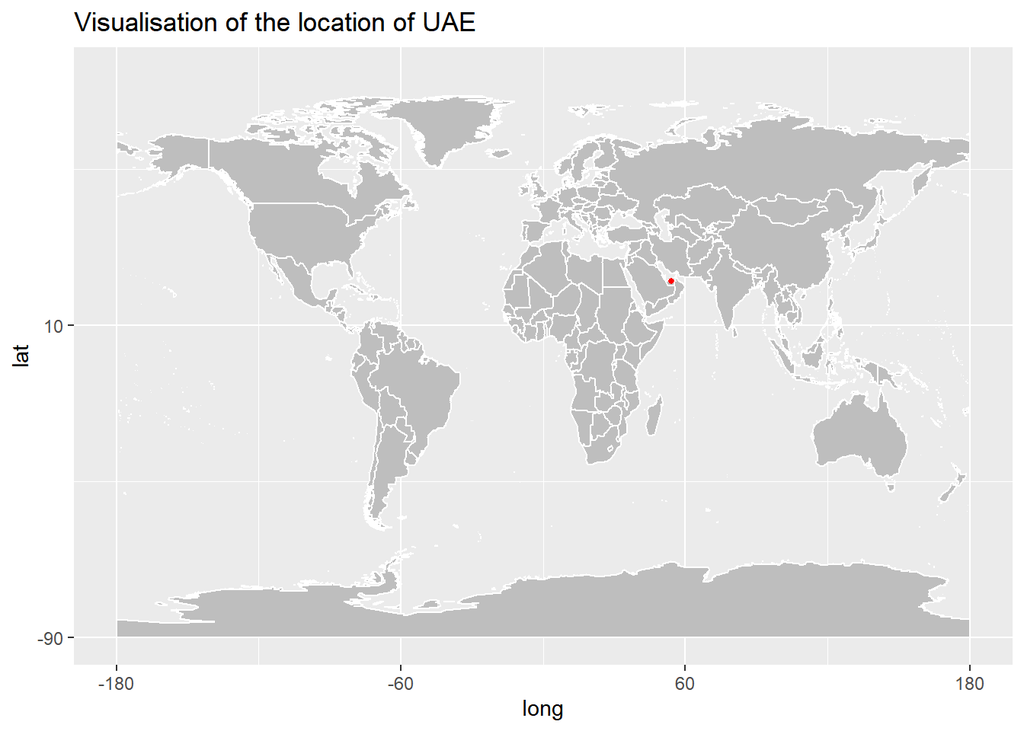

The United Arab Emirates (UAE) has a desert climate ,which has mild winters and very hot, sunny summers. But these days cloudy rainy climate condition.

United Arab Emirates (UAE) has already taken necessary precaution to reduce the spreading of this disease.UAE has ended nationwide coronavirus curfew and lifted restrictions on businesses, including hair salons and cinemas, after three months of stringent curbs, despite a spike in infections.The United Arab Emirates will allow citizens and resident expatriates to travel abroad once they have tested negative for COVID-19 required and in some instances it may be mandatory for the test to be carried out less than 48 hours before departure.

## Exploration Data Analysis

### Description of Dataset

The 2019 Novel Coronavirus COVID-19 (2019-nCoV) dataset provides a daily summary of the Coronavirus (COVID-19) cases(confirmed, death, and recovered) by state/province. (Data period from 22 Januare 2020 to 12 May 2020 )

A data frame with 7 variables

- Date : Date in YYYY-MM-DD format
- Province : Name of province/state, for countries where data is provided split across multiple provinces/states
- Country : Name of country/region
- Lat : Latitude of center of geographic region, defined as either country or, if available, province
- Long : Longitude of center of geographic region, defined as either country or, if available, province
- Type : An indicator for the type of cases (confirmed, death, recovered)
- Cases : Number of cases on given date

### Data

Head Data

```r
head(coronavirus)
```

```
        date province     country lat long      type cases
1 2020-01-22          Afghanistan  33   65 confirmed     0
2 2020-01-23          Afghanistan  33   65 confirmed     0
3 2020-01-24          Afghanistan  33   65 confirmed     0
4 2020-01-25          Afghanistan  33   65 confirmed     0
5 2020-01-26          Afghanistan  33   65 confirmed     0
6 2020-01-27          Afghanistan  33   65 confirmed     0
```

Tail Data

```r
tail(coronavirus)
```

```
            date province country     lat     long      type cases
87803 2020-05-07 Zhejiang   China 29.1832 120.0934 recovered     0
87804 2020-05-08 Zhejiang   China 29.1832 120.0934 recovered     0
87805 2020-05-09 Zhejiang   China 29.1832 120.0934 recovered     0
87806 2020-05-10 Zhejiang   China 29.1832 120.0934 recovered     0
87807 2020-05-11 Zhejiang   China 29.1832 120.0934 recovered     0
87808 2020-05-12 Zhejiang   China 29.1832 120.0934 recovered     0
```

Name of Countries

```r
unique(coronavirus$country)
```

```
  [1] "Afghanistan"                      "Albania"
  [3] "Algeria"                          "Andorra"
  [5] "Angola"                           "Antigua and Barbuda"
  [7] "Argentina"                        "Armenia"
  [9] "Austria"                          "Azerbaijan"
 [11] "Bahamas"                          "Bahrain"
 [13] "Bangladesh"                       "Barbados"
 [15] "Belarus"                          "Belgium"
 [17] "Belize"                           "Benin"
 [19] "Bhutan"                           "Bolivia"
 [21] "Bosnia and Herzegovina"           "Botswana"
 [23] "Brazil"                           "Brunei"
 [25] "Bulgaria"                         "Burkina Faso"
 [27] "Burma"                            "Burundi"
 [29] "Cabo Verde"                       "Cambodia"
```

[output cut: 79 more lines]

### United Arab Emirates Data Analysis

#### Confirmed cases in United Arab Emirates

```
        date province              country lat long      type cases
1 2020-01-22          United Arab Emirates  24   54 confirmed     0
2 2020-01-23          United Arab Emirates  24   54 confirmed     0
3 2020-01-24          United Arab Emirates  24   54 confirmed     0
4 2020-01-25          United Arab Emirates  24   54 confirmed     0
5 2020-01-26          United Arab Emirates  24   54 confirmed     0
6 2020-01-27          United Arab Emirates  24   54 confirmed     0
```

```
          date province              country lat long      type cases
107 2020-05-07          United Arab Emirates  24   54 confirmed   502
108 2020-05-08          United Arab Emirates  24   54 confirmed   553
109 2020-05-09          United Arab Emirates  24   54 confirmed   624
110 2020-05-10          United Arab Emirates  24   54 confirmed   781
111 2020-05-11          United Arab Emirates  24   54 confirmed   680
112 2020-05-12          United Arab Emirates  24   54 confirmed   783
```

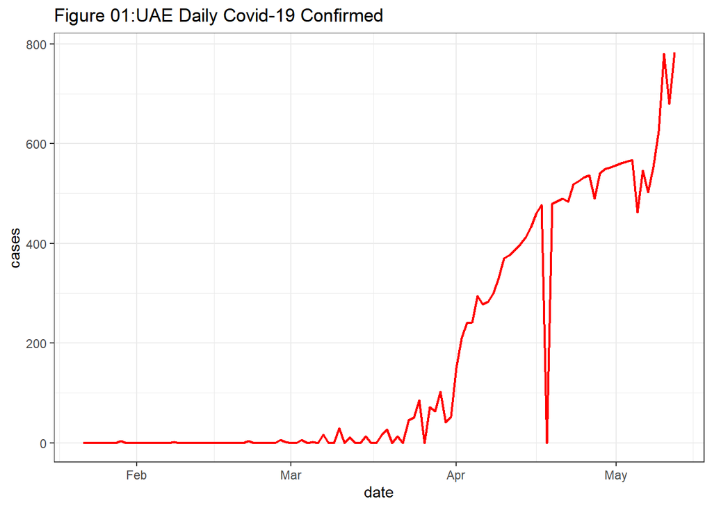

As per figure 01 we can see that the number of confirmed cases were increased from the period 22 January 2020 to 12 May 2020. The maximum confirmed number day is 783 on 12th may 2020.

#### Death head cases in United Arab Emirates

```
        date province              country lat long  type cases
1 2020-01-22          United Arab Emirates  24   54 death     0
2 2020-01-23          United Arab Emirates  24   54 death     0
3 2020-01-24          United Arab Emirates  24   54 death     0
4 2020-01-25          United Arab Emirates  24   54 death     0
5 2020-01-26          United Arab Emirates  24   54 death     0
6 2020-01-27          United Arab Emirates  24   54 death     0
```

```
          date province              country lat long  type cases
107 2020-05-07          United Arab Emirates  24   54 death     8
108 2020-05-08          United Arab Emirates  24   54 death     9
109 2020-05-09          United Arab Emirates  24   54 death    11
110 2020-05-10          United Arab Emirates  24   54 death    13
111 2020-05-11          United Arab Emirates  24   54 death     3
112 2020-05-12          United Arab Emirates  24   54 death     2
```

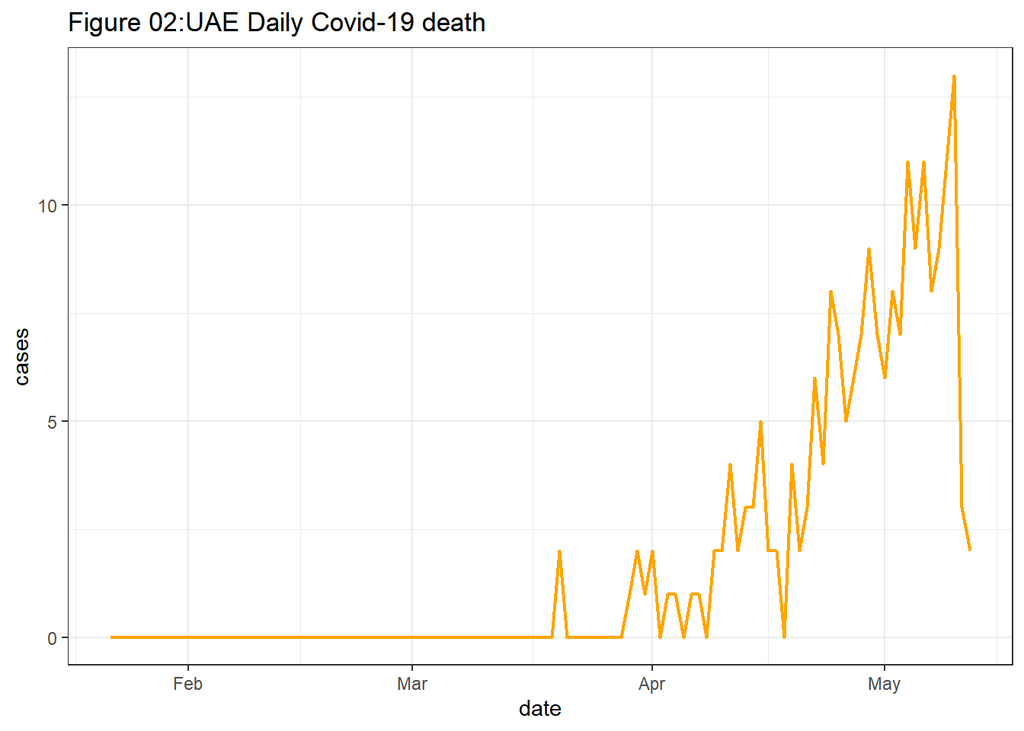

As per figure 02 we can see that the number of death cases were increased from the period 22 January 2020 to 10 May 2020 and sudden decreasing were there during 11th and 12 May. But 13 is the maximum number of death per day during time period .

#### Recovered head cases in United Arab Emirates

```
        date province              country lat long      type cases
1 2020-01-22          United Arab Emirates  24   54 recovered     0
2 2020-01-23          United Arab Emirates  24   54 recovered     0
3 2020-01-24          United Arab Emirates  24   54 recovered     0
4 2020-01-25          United Arab Emirates  24   54 recovered     0
5 2020-01-26          United Arab Emirates  24   54 recovered     0
6 2020-01-27          United Arab Emirates  24   54 recovered     0
```

```
          date province              country lat long      type cases
107 2020-05-07          United Arab Emirates  24   54 recovered   213
108 2020-05-08          United Arab Emirates  24   54 recovered   265
109 2020-05-09          United Arab Emirates  24   54 recovered   458
110 2020-05-10          United Arab Emirates  24   54 recovered   509
111 2020-05-11          United Arab Emirates  24   54 recovered   577
112 2020-05-12          United Arab Emirates  24   54 recovered   631
```

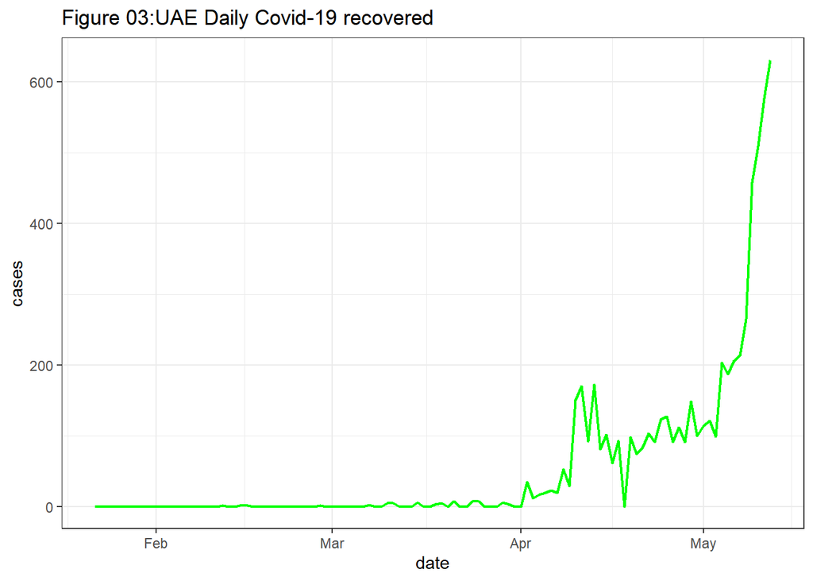

#### Active Cases in United Arab Emirates

```
# A tibble: 112 x 12
   date       province country   lat  long confirmed death recovered active
   <date>     <chr>    <chr>   <dbl> <dbl>     <int> <int>     <int>  <int>
 1 2020-01-22 ""       United~    24    54         0     0         0      0
 2 2020-01-23 ""       United~    24    54         0     0         0      0
 3 2020-01-24 ""       United~    24    54         0     0         0      0
 4 2020-01-25 ""       United~    24    54         0     0         0      0
 5 2020-01-26 ""       United~    24    54         0     0         0      0
 6 2020-01-27 ""       United~    24    54         0     0         0      0
 7 2020-01-28 ""       United~    24    54         0     0         0      0
 8 2020-01-29 ""       United~    24    54         4     0         0      4
 9 2020-01-30 ""       United~    24    54         0     0         0      0
10 2020-01-31 ""       United~    24    54         0     0         0      0
# ... with 102 more rows, and 3 more variables: active_total <int>,
#   recovered_total <int>, death_total <int>
```

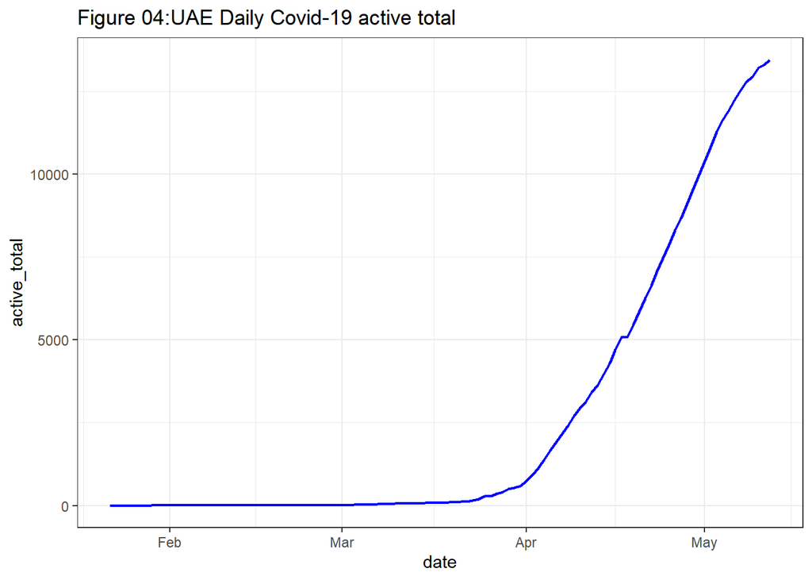

As per figure 04 we can see that the number of active total were increased continuously from the period 22 January 2020 to 12 May 2020.

### Comparison with other countries

#### United Arabic Emirates confirmed cases with Neighboring countries

Iran, Oman, Qatar and Saudi Arabic are the four Neighboring countries which are so close to United Arab Emirates. All these are middle east countries.

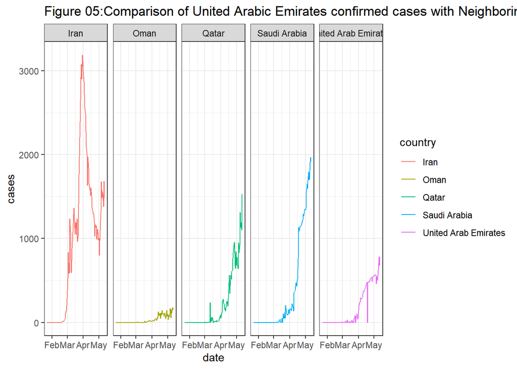

As per figure 05 Saudi Arabia and Qatar have continuous increment, But Iran had a huge increment in begin of the April and control it. Oman is a small country and considering to all other countries , Oman has small number of cases.Large number of cases were confirmed in Iran.

#### United Arabic Emirates confirmed cases with US

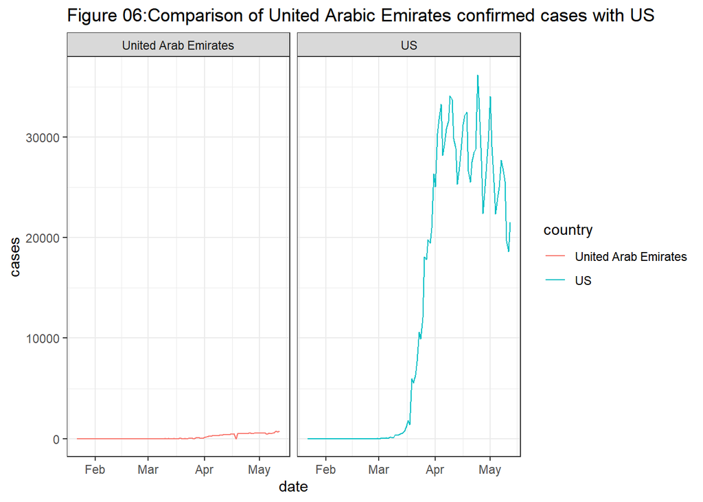

As per figure 06 US has more confirmed cases compare to United Arabic Emirates.

#### United Arabic Emirates confirmed cases with China

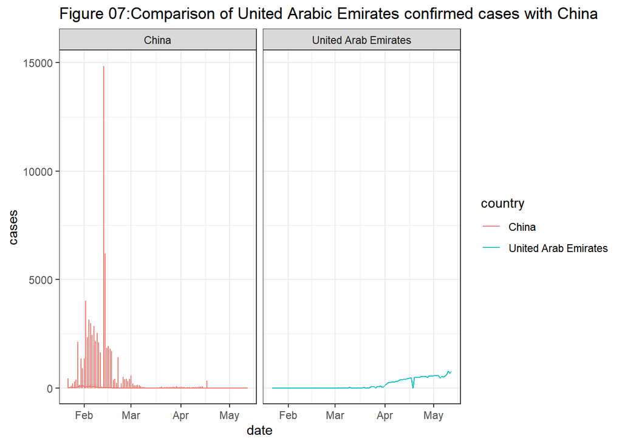

As per figure 07 China has more confirmed cases in the begin of the time period and decrease continuosly from the month of march compared to United Arabic Emirates.

#### Increase distribution of United Arab Emirates , US , Iran , Oman , Qatar and Saudi Arabia

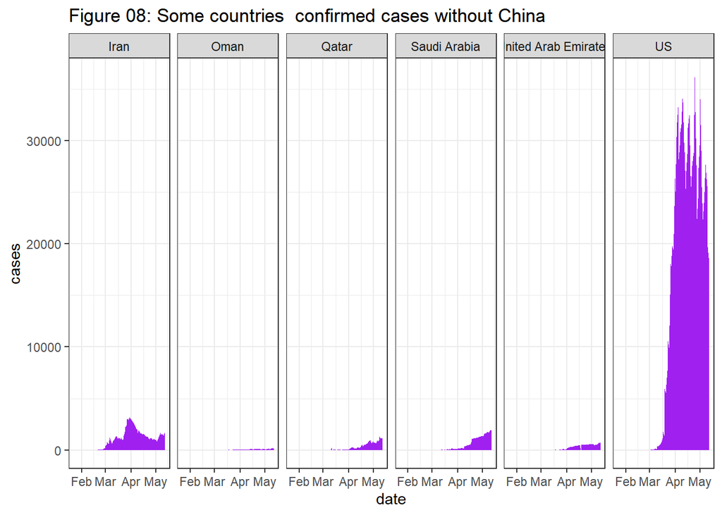

As per figure 08 we can see that US has highest number of confirmed cases than other countries.

## Conclusions and Discussion

Since last year world we are fighting with COVID-19 (coronavirus). This infection disease has been effect not only for human health this effect society very badly . Also people day-today works have been controlled due to this disease.

Coronavirus data set has been limited to 12 th may 2020 and limited to 187 countries. But today it has spread though the world and 215 countries were infected.

United Arab Emirates(UAE) also effected and confirmed cases , daeath and recovered cases had increased during the time period. But in last two days death caese were decrease. (Figures 01,02, and 03) As per the worldometer UAE has been controlled the confirmed and death cases after 12th May 2020.

Among Neighboring countries which has near to United Arabic Emitter Worldometer shows that from other Asian countries Iran was the second highest number of cases recorded country in Asia .Analysis results also confirmed that (check figure 05) among all other Neighboring countries Iran shown the highest number. Also still Iran has been fighting this disease and daily death and confirmed cases were increasing.The second highest number of cases were record in Neighboring countries was Saudi Arabic.Worldometer also confirmed that still Saudi Arabi fighting against COVID 19 and daily increasing the cases.Qatar and Oman Also still fighting against coronavirus and Qatar daily cases were decrease (AS per worldometer from 12th may) but Oman COVID 19 cases were increased after 12th may as per worldometer.

China was the country where coronavirus started. But china frighted and right now China has been controlled the spread of this virus and daily noly few new cases will confirm. Mostly coronavirus was in undercontrolled level.

According to worldometer USA is the highest number of confirmed cases , deaths and recovered was founded. In our result also we can see among all other countries USA shown the highest number of cases.

## Reference

- Praveen Duddu ; “COVID-19 in the Middle East: Coronavirus-affected countries” , 20 march 2020 ; https://www.pharmaceutical-technology.com/features/coronavirus-affected-countries-middle-east-covid-19/
- https://www.doh.gov.ae/covid-19
- Arabian Business/ Industries https://www.arabianbusiness.com/travel-hospitality/449138-uae-allows-citizens-expats-to-travel-abroad
- United Arab Emirates ; Minister of Health & Prevention ;https://www.mohap.gov.ae/en/AwarenessCenter/Pages/COVID-19.aspx
- Worldometer;COVID-19 CORONAVIRUS PANDEMIC; https://www.worldometers.info/coronavirus/?utm_campaign=homeAdUOA?Si